# Manuscript figures and tables

Sabrina Norwood

03 July, 2026

Produces publication-ready figures and tables from previously saved analysis outputs. Outputs saved to `../reports/manuscript/`.

# Dependencies

```r
library(tidyverse)
library(patchwork)
library(flextable)
library(officer)
library(emmeans)
library(lme4)
library(glmmTMB)

dir.create("../reports/manuscript/", showWarnings = FALSE, recursive = TRUE)
```

# Shared helpers

```r
# Add lo/hi columns by parsing a "[lo, hi]" string column
add_ci_cols <- function(df, col = "95% CI") {
  nums <- str_extract_all(df[[col]], "[-0-9.eE+]+") |> map(as.numeric)
  df |> mutate(lo = map_dbl(nums, 1), hi = map_dbl(nums, 2))
}

# Consistent colour palettes
cond_pal   <- c(ABC = "#4477AA", ACC = "#EE6677", BCC = "#228833", CCC = "#CCBB44")
delay_pal  <- c("3" = "#EE6677", "6" = "#228833", "10" = "#4477AA")
cond_order <- c("ABC", "ACC", "BCC", "CCC")

# Shared theme
theme_ms <- function(...) {
  theme_classic(base_size = 12) +
    theme(
      strip.background = element_blank(),
      plot.title       = element_text(size = 11, face = "bold"),
      ...
    )
}

# Minimal flextable formatter
ms_flextable <- function(df, ...) {
  flextable(df, ...) |>
    font(fontname = "Times New Roman", part = "all") |>
    fontsize(size = 10, part = "all") |>
    bold(part = "header") |>
    hline_top(part = "header", border = fp_border(width = 1.5)) |>
    hline_bottom(part = "header", border = fp_border(width = 1)) |>
    hline_bottom(part = "body",   border = fp_border(width = 1.5)) |>
    autofit()
}
```

# Main text tables

## Table 1: Participant flow by condition

```r
df_flow <- read_csv("../reports/results_rq1_tolerability/dropout_summary.csv",
                    show_col_types = FALSE) |>
  mutate(
    condition    = factor(condition, levels = cond_order),
    dropout_rate = sprintf("%.1f%%", dropout_rate)
  ) |>
  arrange(condition) |>
  rename(
    Condition       = condition,
    `N enrolled`    = n_total,
    `N dropped out` = n_dropout,
    `N completed`   = n_complete,
    `Dropout rate`  = dropout_rate
  )

ms_flextable(df_flow) |>
  set_caption("Table 1. Participant flow by condition.")
```

Table 1. Participant flow by condition.

| Condition | N enrolled | N dropped out | N completed | Dropout rate |
| --- | --- | --- | --- | --- |
| ABC | 387 | 251 | 136 | 64.9% |
| ACC | 430 | 288 | 142 | 67.0% |
| BCC | 409 | 288 | 121 | 70.4% |
| CCC | 415 | 275 | 140 | 66.3% |

```r
write_csv(df_flow, "../reports/manuscript/table1_participant_flow.csv")
```

## Table 2: RQ1 logistic regression — dropout by condition

```r
df_rq1_model <- read_csv("../reports/results_rq1_tolerability/model_rq1_results.csv",
                          show_col_types = FALSE) |>
  filter(Predictor != "(Intercept)") |>
  mutate(
    Predictor = str_remove(Predictor, "^condition"),
    Predictor = paste0(Predictor, " vs. CCC")
  ) |>
  rename(
    Condition = Predictor,
    `Odds ratio` = OR,
    `95% CI`     = `95% CI`,
    `p`          = p
  )

ms_flextable(df_rq1_model) |>
  set_caption("Table 2. RQ1: Logistic regression predicting study dropout by condition (reference = CCC).")
```

Table 2. RQ1: Logistic regression predicting study dropout by condition (reference = CCC).

| Condition | Odds ratio | 95% CI | p |
| --- | --- | --- | --- |
| ABC vs. CCC | 0.940 | [0.702, 1.258] | 0.675 |
| ACC vs. CCC | 1.033 | [0.776, 1.375] | 0.826 |
| BCC vs. CCC | 1.212 | [0.903, 1.627] | 0.201 |

```r
write_csv(df_rq1_model, "../reports/manuscript/table2_rq1_model.csv")
```

## Table 3: RQ2 negative binomial regression — dismissed openings and attempts at Week 6

```r
df_rq2_1_model <- read_csv("../reports/results_rq2_effectiveness/model_rq2_1_results.csv",
                            show_col_types = FALSE) |>
  mutate(Outcome = "Dismissed openings (Week 6)")

df_rq2_2_model <- read_csv("../reports/results_rq2_effectiveness/model_rq2_2_results.csv",
                            show_col_types = FALSE) |>
  mutate(Outcome = "Initial attempts (Week 6)")

df_rq2_model <- bind_rows(df_rq2_1_model, df_rq2_2_model) |>
  mutate(
    Predictor = str_remove(Predictor, "^condition"),
    Predictor = if_else(str_detect(Predictor, "^(ABC|ACC|BCC)$"),
                         paste0(Predictor, " vs. CCC"), Predictor)
  ) |>
  select(Outcome, Predictor, `Rate Ratio`, `95% CI`, p)

ms_flextable(df_rq2_model) |>
  set_caption(
    paste("Table 3. RQ2: Negative binomial regression models predicting dismissed openings and",
          "initial app-opening attempts at Week 6, controlling for Week 1 behaviour",
          "(reference condition = CCC).")
  )
```

Table 3. RQ2: Negative binomial regression models predicting dismissed openings and initial app-opening attempts at Week 6, controlling for Week 1 behaviour (reference condition = CCC).

| Outcome | Predictor | Rate Ratio | 95% CI | p |
| --- | --- | --- | --- | --- |
| Dismissed openings (Week 6) | (Intercept) | 0.219 | [0.197, 0.244] | < .001 |
| Dismissed openings (Week 6) | ABC vs. CCC | 1.104 | [0.972, 1.253] | 0.127 |
| Dismissed openings (Week 6) | ACC vs. CCC | 1.099 | [0.968, 1.248] | 0.146 |
| Dismissed openings (Week 6) | BCC vs. CCC | 1.003 | [0.88, 1.144] | 0.96 |
| Dismissed openings (Week 6) | dismissed_w1 | 1.006 | [1.005, 1.008] | < .001 |
| Dismissed openings (Week 6) | attempted_w1 | 0.998 | [0.998, 0.999] | < .001 |
| Initial attempts (Week 6) | (Intercept) | 33.045 | [28.406, 38.57] | < .001 |
| Initial attempts (Week 6) | ABC vs. CCC | 1.020 | [0.855, 1.216] | 0.828 |
| Initial attempts (Week 6) | ACC vs. CCC | 0.830 | [0.697, 0.988] | 0.036 |
| Initial attempts (Week 6) | BCC vs. CCC | 1.019 | [0.85, 1.222] | 0.841 |
| Initial attempts (Week 6) | attempted_w1 | 1.005 | [1.005, 1.006] | < .001 |

```r
write_csv(df_rq2_model, "../reports/manuscript/table3_rq2_model.csv")
```

# Main text figures

## Figure 1: Participant flow diagram

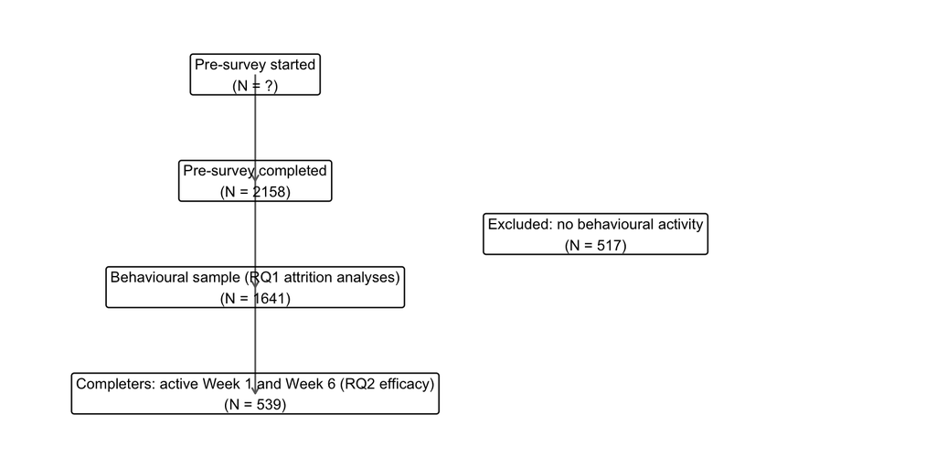

```r
# NOTE: the pre-survey "started" count (4,483 in the manuscript draft) is not
# computed anywhere in 01_processing_behavioral_data.Rmd or
# 02_processing_surveys.Rmd. Confirm its source (raw Qualtrics export row
# count) and set it explicitly here before using this figure -- do not
# hardcode a number that hasn't been traced back to a script.
n_presurvey_started   <- NA_integer_   # TODO: confirm and fill in
n_presurvey_completed <- 2158
n_behavioral          <- 1641
n_excluded_no_activity <- n_presurvey_completed - n_behavioral
n_completers_w1w6     <- 539

flow_boxes <- tribble(
  ~step, ~label,                                                ~n,   ~x, ~y,
  1,     "Pre-survey started",                                  n_presurvey_started,   0, 5,
  2,     "Pre-survey completed",                                n_presurvey_completed, 0, 4,
  3,     "Excluded: no behavioural activity",                   n_excluded_no_activity, 1.6, 3.5,
  4,     "Behavioural sample (RQ1 attrition analyses)",         n_behavioral,           0, 3,
  5,     "Completers: active Week 1 and Week 6 (RQ2 efficacy)", n_completers_w1w6,      0, 2
) |>
  mutate(text = paste0(label, "\n(N = ", ifelse(is.na(n), "?", n), ")"))

p_flow <- ggplot(flow_boxes) +
  geom_segment(data = filter(flow_boxes, step %in% c(1,2,4,5)),
               aes(x = x, xend = x, y = y, yend = lead(y)),
               linewidth = 0.5, colour = "grey40",
               arrow = arrow(length = unit(0.15, "cm")), na.rm = TRUE) +
  geom_label(aes(x = x, y = y, label = text), size = 3.2, label.size = 0.4,
             hjust = 0.5) +
  coord_cartesian(xlim = c(-1, 3), ylim = c(1.5, 5.5)) +
  theme_void()

p_flow
```

```r
ggsave("../reports/manuscript/figure1_participant_flow.png",
       p_flow, width = 6, height = 6, dpi = 300)
```

## Figure 2: Attrition by week

Weekly proportion of participants dropping out (last active week), by condition.

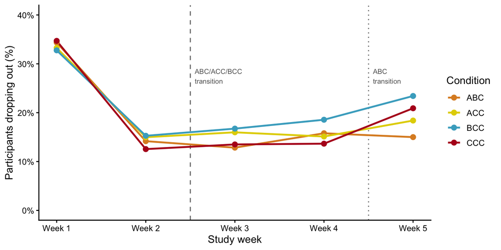

```r
if (!requireNamespace("wesanderson", quietly = TRUE)) {
  install.packages("wesanderson", repos = "https://cloud.r-project.org")
}
library(wesanderson)

fox_subset <- wes_palette("FantasticFox1")[c(1, 2, 3, 5)]
df_weekly_raw <- read_csv("../reports/results_rq1_tolerability/weekly_dropout_counts.csv",
                           show_col_types = FALSE)

df_n_total <- read_csv("../reports/results_rq1_tolerability/dropout_summary.csv",
                        show_col_types = FALSE) |>
  select(condition, n_total)

df_weekly <- df_weekly_raw |>
  pivot_longer(-last_week,
               names_to    = "condition",
               names_prefix = "n_dropouts_",
               values_to   = "n_dropout") |>
  left_join(df_n_total, by = "condition") |>
  arrange(condition, last_week) |>
  group_by(condition) |>
  mutate(
    # at-risk this week = total N minus everyone who dropped out in prior weeks
    n_at_risk   = n_total - lag(cumsum(n_dropout), default = 0),
    pct_dropout = n_dropout / n_at_risk * 100,
    condition   = factor(condition, levels = cond_order)
  ) |>
  ungroup()

wes_pal <- wes_palette("FantasticFox1", n = length(cond_order))

p_fig1 <- ggplot(df_weekly,
                 aes(x = last_week, y = pct_dropout,
                     colour = condition, group = condition)) +
  # Transition at start of Week 3: ABC, ACC, BCC change delay
  geom_vline(xintercept = 2.5, linetype = "dashed", colour = "grey50", linewidth = 0.6) +
  # Transition at start of Week 5: ABC only (6s → 10s)
  geom_vline(xintercept = 4.5, linetype = "dotted", colour = "grey50", linewidth = 0.6) +
  annotate("text", x = 2.55, y = 29, label = "ABC/ACC/BCC\ntransition",
           hjust = 0, vjust = 1, size = 2.8, colour = "grey40") +
  annotate("text", x = 4.55, y = 29, label = "ABC\ntransition",
           hjust = 0, vjust = 1, size = 2.8, colour = "grey40") +
  geom_line(linewidth = 1) +
  geom_point(size = 2.5) +
  scale_x_continuous(breaks = 1:5,
                     labels = paste("Week", 1:5)) +
  scale_y_continuous(labels = scales::percent_format(scale = 1, accuracy = 1),
                     limits = c(0, 40),
                     breaks = seq(0, 40, by = 10)) +
  scale_colour_manual(values = fox_subset) +
  labs(
    x      = "Study week",
    y      = "Participants dropping out (%)",
    colour = "Condition"
  ) +
  theme_ms()

p_fig1
```

```r
ggsave("../reports/manuscript/figure2_attrition_by_week.png",
       p_fig1, width = 6, height = 4, dpi = 300)
```

## Load weekly data for dose-response figures

Source data and centring constants for the exploratory GLMMs (matches the parameterisation in `04_analysis_rq2_effectiveness.Rmd`). Loaded once here so both dose-response panels below are self-contained and reproducible without depending on objects left over from another script’s session.

```r
weekly_raw <- read_csv("../data/processed/data_processed_behavioral_data_weekly.csv",
                       show_col_types = FALSE)

delay_mean <- mean(weekly_raw$delay_secs)
week_mean  <- mean(weekly_raw$study_week)

m_attempts <- read_rds("../reports/results_rq2_effectiveness/glmm_attempts.rds")
m_dismiss  <- read_rds("../reports/results_rq2_effectiveness/glmm_dismiss.rds")
```

## Figure 3: RQ2 estimated means at Week 6 (preregistered)

Both panels show model-estimated marginal means (± 95% CI) from the preregistered negative binomial models, adjusted for Week 1 behaviour. Panel A shows the dismissal rate (dismissed openings per attempt) and Panel B shows total app-opening attempts — presented together because they reflect two complementary aspects of the same RQ2 outcome measure at Week 6.

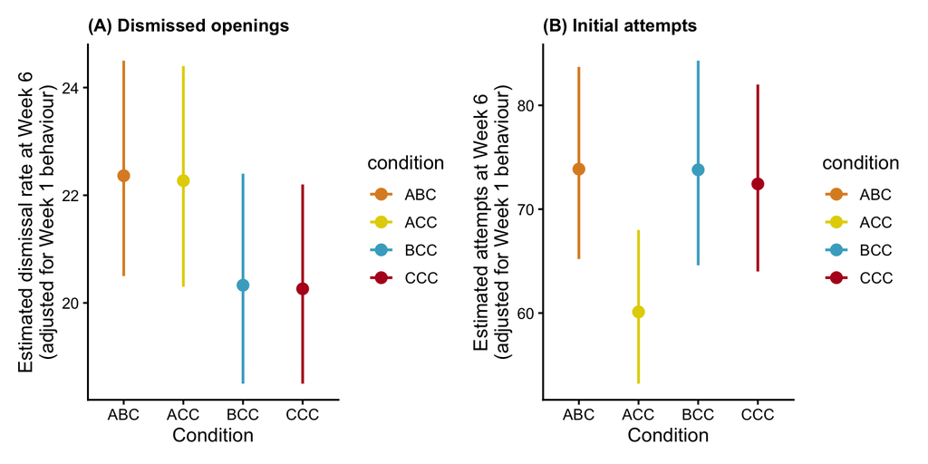

```r
df_emm_dis <- read_csv("../reports/results_rq2_effectiveness/emmeans_rq2_1.csv",
                        show_col_types = FALSE) |>
  add_ci_cols() |>
  mutate(condition = factor(Condition, levels = cond_order))

p3a <- ggplot(df_emm_dis,
              aes(x = condition,
                  y = `Dismissals per attempt`,
                  ymin = lo, ymax = hi,
                  colour = condition)) +
  geom_point(size = 3) +
  geom_errorbar(width = 0, linewidth = 0.8) +
  scale_colour_manual(values = fox_subset) +
  labs(
    x     = "Condition",
    y     = "Estimated dismissal rate at Week 6\n(adjusted for Week 1 behaviour)",
    title = "(A) Dismissed openings"
  ) +
  theme_ms()

df_emm_att <- read_csv("../reports/results_rq2_effectiveness/emmeans_rq2_2.csv",
                        show_col_types = FALSE) |>
  add_ci_cols() |>
  mutate(condition = factor(Condition, levels = cond_order))

p3b <- ggplot(df_emm_att,
              aes(x = condition, y = `Mean attempts`, ymin = lo, ymax = hi,
                  colour = condition)) +
  geom_point(size = 3) +
  geom_errorbar(width = 0, linewidth = 0.8) +
  scale_colour_manual(values = fox_subset) +
  labs(
    x     = "Condition",
    y     = "Estimated attempts at Week 6\n(adjusted for Week 1 behaviour)",
    title = "(B) Initial attempts"
  ) +
  theme_ms()

fig3 <- p3a + p3b

fig3
```

```r
ggsave("../reports/manuscript/figure3_rq2_week6_emmeans.png",
       fig3, width = 9, height = 4.5, dpi = 300)
```

## Figure 4: Exploratory dose-response trajectories

Panel A: predicted attempt count by delay length and study week (exploratory negative binomial GLMM; observed cells only). Panel B: predicted dismissal probability by delay length and study week (exploratory binomial GLMM; observed cells only). Not preregistered.

```r
plot_data_att <- emmeans(
  m_attempts, ~ delay_secs_c * study_week_c,
  at   = list(
    delay_secs_c = c(3, 6, 10) - delay_mean,
    study_week_c = (1:6) - week_mean
  ),
  type = "response",
  data = weekly_raw |>
    mutate(
      delay_secs_c = delay_secs - delay_mean,
      study_week_c = study_week - week_mean
    )
) |>
  summary(infer = TRUE) |>
  as_tibble() |>
  mutate(
    delay_secs  = round(delay_secs_c + delay_mean),
    study_week  = round(study_week_c + week_mean),
    `Delay (s)` = factor(delay_secs)
  )

observed_cells_att <- weekly_raw |>
  distinct(delay_secs, study_week)

plot_data_att_obs <- plot_data_att |>
  semi_join(observed_cells_att, by = c("delay_secs", "study_week"))

p4a <- ggplot(plot_data_att_obs,
              aes(study_week, response,
                  colour = `Delay (s)`, fill = `Delay (s)`,
                  group  = `Delay (s)`)) +
  geom_ribbon(aes(ymin = asymp.LCL, ymax = asymp.UCL),
              alpha = 0.15, colour = NA) +
  geom_line(linewidth = 1) +
  geom_point(size = 2) +
  scale_x_continuous(breaks = 1:6) +
  scale_colour_manual(values = delay_pal) +
  scale_fill_manual(values = delay_pal) +
  labs(
    x      = "Study week",
    y      = "Predicted weekly attempts",
    colour = "Delay (s)",
    fill   = "Delay (s)",
    title  = "(A) Attempts"
  ) +
  theme_ms()
```

```r
weekly_dismiss_c <- weekly_raw |>
  filter(attempted > 0) |>
  mutate(
    delay_secs_c = delay_secs - delay_mean,
    study_week_c = study_week - week_mean
  )

plot_data_dis <- emmeans(
  m_dismiss, ~ delay_secs_c * study_week_c,
  at   = list(
    delay_secs_c = c(3, 6, 10) - delay_mean,
    study_week_c = (1:6) - week_mean
  ),
  type = "response",
  data = weekly_dismiss_c
) |>
  summary(infer = TRUE) |>
  as_tibble() |>
  mutate(
    delay_secs  = round(delay_secs_c + delay_mean),
    study_week  = round(study_week_c + week_mean),
    `Delay (s)` = factor(delay_secs)
  )

observed_cells_dis <- weekly_dismiss_c |>
  distinct(delay_secs, study_week)

plot_data_dis_obs <- plot_data_dis |>
  semi_join(observed_cells_dis, by = c("delay_secs", "study_week"))

p4b <- ggplot(plot_data_dis_obs,
              aes(study_week, prob,
                  colour = `Delay (s)`, fill = `Delay (s)`,
                  group  = `Delay (s)`)) +
  geom_ribbon(aes(ymin = asymp.LCL, ymax = asymp.UCL),
              alpha = 0.15, colour = NA) +
  geom_line(linewidth = 1) +
  geom_point(size = 2) +
  scale_x_continuous(breaks = 1:6) +
  scale_y_continuous(labels = scales::percent_format(accuracy = 1)) +
  scale_colour_manual(values = delay_pal) +
  scale_fill_manual(values = delay_pal) +
  labs(
    x      = "Study week",
    y      = "Predicted dismissal probability",
    colour = "Delay (s)",
    fill   = "Delay (s)",
    title  = "(B) Dismissed openings"
  ) +
  theme_ms()
```

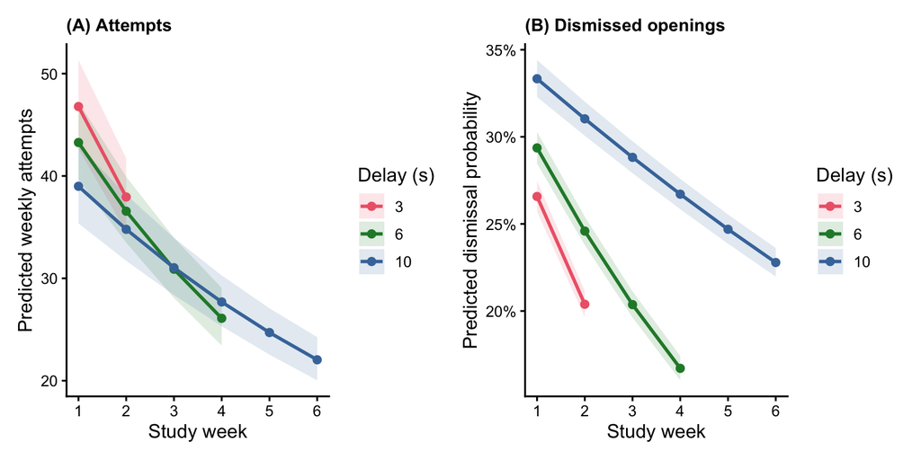

```r
fig4 <- p4a + p4b

fig4
```

```r
ggsave("../reports/manuscript/figure4_dose_response.png",
       fig4, width = 10, height = 4.5, dpi = 300)
```

# Supplemental materials

## Figure S1: RQ1 tolerability — predicted dropout probability by condition (preregistered vs. dose-response hazard model)

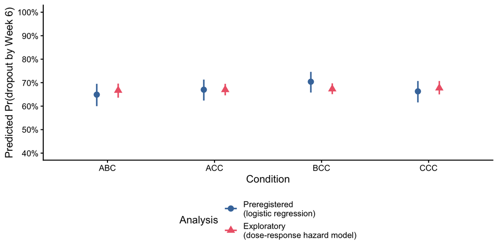

```r
df_emm_logistic <- read_csv("../reports/results_rq1_tolerability/emmeans_rq1.csv",
                              show_col_types = FALSE) |>
  add_ci_cols() |>
  mutate(
    condition = factor(Condition, levels = cond_order),
    analysis  = "Preregistered\n(logistic regression)"
  ) |>
  rename(est = `Pr(dropout)`)

df_emm_hazard <- read_csv("../reports/results_rq1_tolerability/hazard_by_condition_emmeans.csv",
                            show_col_types = FALSE) |>
  add_ci_cols() |>
  mutate(
    condition = factor(Condition, levels = cond_order),
    analysis  = "Exploratory\n(dose-response hazard model)"
  ) |>
  rename(est = `Pr(dropout)`)

df_emm_rq1 <- bind_rows(df_emm_logistic, df_emm_hazard) |>
  mutate(analysis = factor(analysis, levels = c(
    "Preregistered\n(logistic regression)",
    "Exploratory\n(dose-response hazard model)"
  )))

p_rq1 <- ggplot(df_emm_rq1, aes(x = condition, y = est,
                                   colour = analysis, shape = analysis)) +
  geom_point(size = 3, position = position_dodge(width = 0.4)) +
  geom_errorbar(aes(ymin = lo, ymax = hi),
                width = 0, linewidth = 0.8,
                position = position_dodge(width = 0.4)) +
  scale_y_continuous(labels = scales::percent_format(accuracy = 1),
                     limits = c(0.4, 1),
                     breaks = seq(0.4, 1, by = 0.1)) +
  scale_colour_manual(values = c("#4477AA", "#EE6677")) +
  scale_shape_manual(values = c(16, 17)) +
  labs(
    x      = "Condition",
    y      = "Predicted Pr(dropout by Week 6)",
    colour = "Analysis",
    shape  = "Analysis"
  ) +
  theme_ms(legend.position = "bottom") +
  guides(colour = guide_legend(nrow = 2), shape = guide_legend(nrow = 2))

p_rq1
```

```r
ggsave("../reports/manuscript/figureS1_rq1_tolerability.png",
       p_rq1, width = 6, height = 5, dpi = 300)
```

## Table S3: RQ2 pairwise comparisons — dismissed openings and attempts at Week 6

```r
df_pw1 <- read_csv("../reports/results_rq2_effectiveness/pairwise_rq2_1.csv",
                    show_col_types = FALSE) |>
  mutate(Outcome = "Dismissed openings (Week 6)")

df_pw2 <- read_csv("../reports/results_rq2_effectiveness/pairwise_rq2_2.csv",
                    show_col_types = FALSE) |>
  mutate(Outcome = "Initial attempts (Week 6)")

df_pw_all <- bind_rows(df_pw1, df_pw2) |>
  mutate(across(where(is.numeric), ~ round(.x, 3))) |>
  mutate(`95% CI` = paste0("[", asymp.LCL, ", ", asymp.UCL, "]")) |>
  select(
    Outcome,
    Contrast     = contrast,
    `Rate ratio` = ratio,
    SE,
    `95% CI`,
    `z`          = z.ratio,
    `p`          = p
  )

ms_flextable(df_pw_all) |>
  set_caption(
    paste("Table S3. RQ2: Pairwise comparisons of model-estimated dismissed openings and",
          "initial attempt counts at Week 6 (negative binomial regression; unadjusted p-values).")
  )
```

Table S3. RQ2: Pairwise comparisons of model-estimated dismissed openings and initial attempt counts at Week 6 (negative binomial regression; unadjusted p-values).

| Outcome | Contrast | Rate ratio | SE | 95% CI | z | p |
| --- | --- | --- | --- | --- | --- | --- |
| Dismissed openings (Week 6) | CCC / ABC | 0.906 | 0.059 | [0.798, 1.029] | -1.525 | 0.127 |
| Dismissed openings (Week 6) | CCC / ACC | 0.910 | 0.059 | [0.801, 1.033] | -1.454 | 0.146 |
| Dismissed openings (Week 6) | CCC / BCC | 0.997 | 0.067 | [0.874, 1.136] | -0.050 | 0.960 |
| Dismissed openings (Week 6) | ABC / ACC | 1.004 | 0.065 | [0.885, 1.139] | 0.065 | 0.948 |
| Dismissed openings (Week 6) | ABC / BCC | 1.100 | 0.073 | [0.965, 1.254] | 1.429 | 0.153 |
| Dismissed openings (Week 6) | ACC / BCC | 1.095 | 0.074 | [0.96, 1.25] | 1.357 | 0.175 |
| Initial attempts (Week 6) | CCC / ABC | 0.981 | 0.088 | [0.822, 1.169] | -0.217 | 0.828 |
| Initial attempts (Week 6) | CCC / ACC | 1.205 | 0.107 | [1.012, 1.434] | 2.095 | 0.036 |
| Initial attempts (Week 6) | CCC / BCC | 0.982 | 0.091 | [0.819, 1.177] | -0.201 | 0.841 |
| Initial attempts (Week 6) | ABC / ACC | 1.229 | 0.110 | [1.031, 1.465] | 2.298 | 0.022 |
| Initial attempts (Week 6) | ABC / BCC | 1.001 | 0.093 | [0.834, 1.202] | 0.010 | 0.992 |
| Initial attempts (Week 6) | ACC / BCC | 0.815 | 0.075 | [0.68, 0.976] | -2.218 | 0.027 |

```r
write_csv(df_pw_all, "../reports/manuscript/tableS3_rq2_pairwise.csv")
```

## Table S4: Exploratory GLMM fixed effects — attempts and dismissed openings

```r
df_glmm_att <- read_csv("../reports/results_rq2_effectiveness/glmm_attempts_results.csv",
                          show_col_types = FALSE) |>
  mutate(Outcome = "App-opening attempts (NB GLMM)")

df_glmm_dis <- read_csv("../reports/results_rq2_effectiveness/glmm_dismiss_results.csv",
                          show_col_types = FALSE) |>
  mutate(Outcome = "Dismissed openings (binomial GLMM)")

df_glmm_all <- bind_rows(df_glmm_att, df_glmm_dis) |>
  mutate(
    Predictor = recode(Predictor,
      "(Intercept)"              = "Intercept",
      "delay_secs_c"             = "Delay (seconds, centred)",
      "study_week_c"             = "Study week (centred)",
      "delay_secs_c:study_week_c" = "Delay × Week"
    )
  ) |>
  select(Outcome, Predictor, everything())

ms_flextable(df_glmm_all) |>
  set_caption(
    paste("Table S4. Exploratory GLMM fixed effects for app-opening attempts",
          "(negative binomial, IRRs) and dismissed openings (binomial, ORs).",
          "Predictors are mean-centred. Reference: mean delay (7.5s), mean week (2.9).")
  )
```

Table S4. Exploratory GLMM fixed effects for app-opening attempts (negative binomial, IRRs) and dismissed openings (binomial, ORs). Predictors are mean-centred. Reference: mean delay (7.5s), mean week (2.9).

| Outcome | Predictor | Rate Ratio | 95% CI | p | OR |
| --- | --- | --- | --- | --- | --- |
| App-opening attempts (NB GLMM) | Intercept | 31.450 | [28.75, 34.404] | < .001 |  |
| App-opening attempts (NB GLMM) | Delay (seconds, centred) | 1.000 | [0.988, 1.011] | 0.962 |  |
| App-opening attempts (NB GLMM) | Study week (centred) | 0.863 | [0.847, 0.879] | < .001 |  |
| App-opening attempts (NB GLMM) | Delay × Week | 1.014 | [1.008, 1.02] | < .001 |  |
| Dismissed openings (binomial GLMM) | Intercept |  | [0.298, 0.326] | < .001 | 0.312 |
| Dismissed openings (binomial GLMM) | Delay (seconds, centred) |  | [1.112, 1.123] | < .001 | 1.118 |
| Dismissed openings (binomial GLMM) | Study week (centred) |  | [0.821, 0.833] | < .001 | 0.827 |
| Dismissed openings (binomial GLMM) | Delay × Week |  | [1.032, 1.037] | < .001 | 1.035 |

```r
write_csv(df_glmm_all, "../reports/manuscript/tableS4_glmm_fixed_effects.csv")
```

## Table S5: Exploratory GLMM per-week delay slopes — attempts and dismissed openings

```r
df_slopes_att <- read_csv("../reports/results_rq2_effectiveness/glmm_attempts_slopes.csv",
                            show_col_types = FALSE) |>
  mutate(Outcome = "App-opening attempts (IRR per second of delay)")

df_slopes_dis <- read_csv("../reports/results_rq2_effectiveness/glmm_dismiss_slopes.csv",
                            show_col_types = FALSE) |>
  mutate(Outcome = "Dismissed openings (OR per second of delay)")

df_slopes_all <- bind_rows(df_slopes_att, df_slopes_dis) |>
  select(Outcome, `Study week`, everything())

ms_flextable(df_slopes_all) |>
  set_caption(
    paste("Table S5. Exploratory GLMM: estimated effect of delay duration",
          "(per additional second) on app-opening attempts and dismissed openings",
          "at Weeks 1, 3, and 6, derived from the delay × week interaction.")
  )
```

Table S5. Exploratory GLMM: estimated effect of delay duration (per additional second) on app-opening attempts and dismissed openings at Weeks 1, 3, and 6, derived from the delay × week interaction.

| Outcome | Study week | RR per sec of delay | 95% CI | p | OR per sec of delay |
| --- | --- | --- | --- | --- | --- |
| App-opening attempts (IRR per second of delay) | 1 | 0.974 | [0.964, 0.985] | < .001 |  |
| App-opening attempts (IRR per second of delay) | 3 | 1.000 | [0.989, 1.01] | 0.843 |  |
| App-opening attempts (IRR per second of delay) | 6 | 1.040 | [1.02, 1.07] | 0.002 |  |
| Dismissed openings (OR per second of delay) | 1 |  | [1.04, 1.05] | < .001 | 1.05 |
| Dismissed openings (OR per second of delay) | 3 |  | [1.12, 1.13] | < .001 | 1.12 |
| Dismissed openings (OR per second of delay) | 6 |  | [1.23, 1.26] | < .001 | 1.24 |

```r
write_csv(df_slopes_all, "../reports/manuscript/tableS5_glmm_slopes.csv")
```

## Table S1: RQ3 satisfaction descriptives by condition

```r
df_post <- read_csv("../data/processed/data_processed_selfreport_post.csv",
                     show_col_types = FALSE) |>
  mutate(condition = factor(condition, levels = cond_order))

satisfaction_items <- c(
  solved_problems  = "Solved consumption problems",
  achieved_goals   = "Achieved consumption goals",
  helpful_problems = "Helpful for solving problems",
  helpful_goals    = "Helpful for achieving goals",
  satisfied_interv = "Satisfied with intervention",
  satisfied_progr  = "Satisfied with progress"
)

df_sat_raw <- map_dfr(names(satisfaction_items), function(item) {
  df_post |>
    group_by(condition) |>
    summarise(
      item = item,
      n    = sum(!is.na(.data[[item]])),
      mean = round(mean(.data[[item]], na.rm = TRUE), 2),
      sd   = round(sd(.data[[item]],   na.rm = TRUE), 2),
      .groups = "drop"
    )
}) |>
  mutate(Item = satisfaction_items[item])

df_sat <- df_sat_raw |>
  mutate(`M (SD)` = paste0(mean, " (", sd, ")")) |>
  select(Item, Condition = condition, n, `M (SD)`) |>
  pivot_wider(names_from = Condition, values_from = c(n, `M (SD)`),
              names_glue = "{Condition}_{.value}") |>
  select(Item,
         starts_with("ABC"), starts_with("ACC"),
         starts_with("BCC"), starts_with("CCC"))

names(df_sat) <- names(df_sat) |>
  str_replace("_n$", " n") |>
  str_replace("_M \\(SD\\)$", " M (SD)")

ms_flextable(df_sat) |>
  set_caption(
    "Table S1. RQ3: Satisfaction descriptives (means and SDs on 1–7 scales) by condition."
  )
```

Table S1. RQ3: Satisfaction descriptives (means and SDs on 1–7 scales) by condition.

| Item | ABC n | ABC M (SD) | ACC n | ACC M (SD) | BCC n | BCC M (SD) | CCC n | CCC M (SD) |
| --- | --- | --- | --- | --- | --- | --- | --- | --- |
| Solved consumption problems | 48 | 4.48 (1.41) | 46 | 4.3 (1.33) | 49 | 4.37 (1.44) | 56 | 4.62 (1.3) |
| Achieved consumption goals | 48 | 4.6 (1.54) | 46 | 4.41 (1.54) | 49 | 4.24 (1.65) | 56 | 4.71 (1.4) |
| Helpful for solving problems | 48 | 5.65 (1.23) | 46 | 5.57 (0.96) | 49 | 5.55 (0.96) | 56 | 5.75 (0.94) |
| Helpful for achieving goals | 48 | 5.54 (1.11) | 46 | 5.41 (1.07) | 49 | 5.39 (1.04) | 56 | 5.46 (1.22) |
| Satisfied with intervention | 48 | 5.73 (1.12) | 46 | 5.52 (0.75) | 49 | 5.61 (1.2) | 56 | 5.5 (1.06) |
| Satisfied with progress | 48 | 5.38 (1.33) | 46 | 5.04 (1.28) | 49 | 5.06 (1.2) | 56 | 5.43 (1.14) |

```r
write_csv(df_sat, "../reports/manuscript/tableS1_rq3_satisfaction.csv")
```

## Table S2: RQ5 preferred delay pattern

Among respondents who expressed a preference for increasing delays (`prefer_increasing == "Yes"`).

```r
# NOTE: Pattern option labels (Option 1/2/3) come from the survey instrument.
# Add a Description column here once you confirm what each option means.

df_pref <- df_post |>
  filter(prefer_increasing == "Yes", !is.na(pref_pattern)) |>
  count(pref_pattern) |>
  mutate(pct = round(n / sum(n) * 100, 1)) |>
  arrange(desc(n)) |>
  select(Pattern = pref_pattern, N = n, `%` = pct) |>
  mutate(`%` = paste0(`%`, "%"))

cat("Preferred pattern N (among prefer_increasing == 'Yes'):", sum(df_pref$N), "\n")
```

```
## Preferred pattern N (among prefer_increasing == 'Yes'): 163
```

```r
ms_flextable(df_pref) |>
  set_caption(
    paste0("Table S2. RQ5: Preferred delay pattern among post-survey completers who preferred ",
           "increasing delays (N = ", sum(df_pref$N), ").")
  )
```

Table S2. RQ5: Preferred delay pattern among post-survey completers who preferred increasing delays (N = 163).

| Pattern | N | % |
| --- | --- | --- |
| Option 1 | 76 | 46.6% |
| Option 3 | 61 | 37.4% |
| Other | 15 | 9.2% |
| Option 2 | 11 | 6.7% |

```r
write_csv(df_pref, "../reports/manuscript/tableS2_rq5_preferred_pattern.csv")
```

## Figure S2: RQ2 within-condition change from Week 1 to Week 6

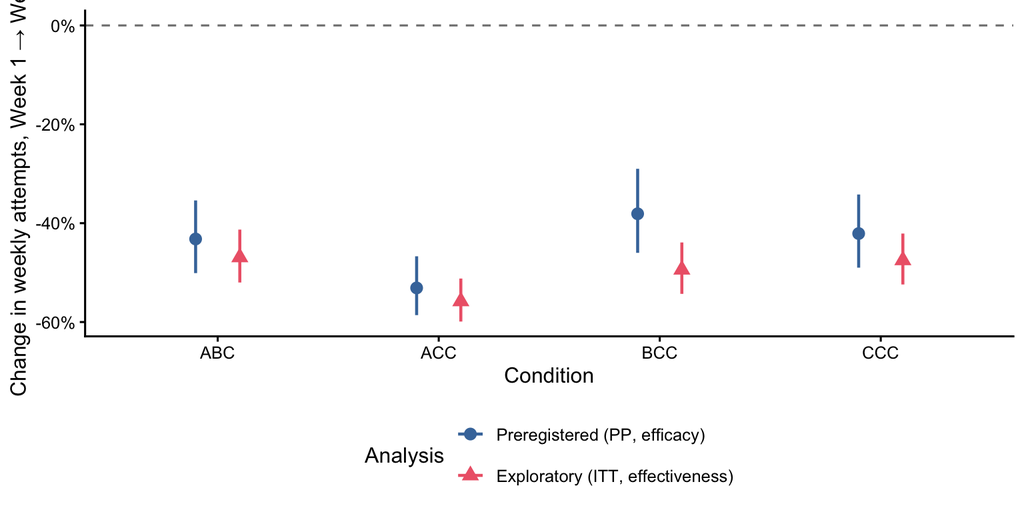

```r
df_change <- read_csv(
  "../reports/results_rq2_effectiveness/combined_prop_change.csv",
  show_col_types = FALSE
) |>
  add_ci_cols() |>
  mutate(
    condition   = factor(Condition, levels = cond_order),
    Analysis    = factor(Analysis, levels = unique(Analysis)),
    prop_change = as.numeric(str_remove(`Prop. change`, "%"))
  )

p_s1 <- ggplot(df_change,
               aes(x = condition, y = prop_change,
                   colour = Analysis, shape = Analysis)) +
  geom_hline(yintercept = 0, linetype = "dashed", colour = "grey50") +
  geom_point(size = 3, position = position_dodge(width = 0.4)) +
  geom_errorbar(aes(ymin = lo, ymax = hi),
                width = 0, linewidth = 0.8,
                position = position_dodge(width = 0.4)) +
  scale_y_continuous(labels = scales::percent_format(scale = 1, accuracy = 1)) +
  scale_colour_manual(values = c("#4477AA", "#EE6677")) +
  scale_shape_manual(values = c(16, 17)) +
  labs(
    x      = "Condition",
    y      = "Change in weekly attempts, Week 1 → Week 6",
    colour = "Analysis",
    shape  = "Analysis"
  ) +
  theme_ms(legend.position = "bottom") +
  guides(colour = guide_legend(nrow = 2), shape = guide_legend(nrow = 2))

p_s1
```

```r
ggsave("../reports/manuscript/figureS1_rq2_prop_change.png",
       p_s1, width = 6, height = 5, dpi = 300)
```

# Summary of outputs

```r
outputs <- list.files("../reports/manuscript/", full.names = FALSE)
cat("Files saved to reports/manuscript/:\n")
```

```
## Files saved to reports/manuscript/:
```

```r
cat(paste0("  ", outputs), sep = "\n")
```

```
##   figure1_attrition_by_week.png
##   figure1_participant_flow.png
##   figure1_rq1_tolerability.png
##   figure2_attrition_by_week.png
##   figure2_rq2_attempts_w6.png
##   figure2_rq2_attempts.png
##   figure3_rq2_dismissals.png
##   figure3_rq2_week6_emmeans.png
##   figure4_dose_response.png
##   figureS1_rq1_tolerability.png
##   figureS1_rq2_prop_change.png
##   table1_participant_flow.csv
##   table2_rq1_model.csv
##   table3_rq2_model.csv
##   table3_rq2_pairwise_attempts.csv
##   tableS1_rq3_satisfaction.csv
##   tableS2_rq5_preferred_pattern.csv
##   tableS3_rq2_pairwise.csv
##   tableS4_glmm_fixed_effects.csv
##   tableS5_glmm_slopes.csv
```